# HW 7

Jacob Harrell

4/18/2021

## R Markdown

**Question 1**

Place the data into unmarkedFrameOccu objects.

```r
#setwd(choose.dir('HW7'))
library(unmarked)
#the count data
y <- read.csv('Bobcat.csv')
bob_mat <- as.matrix(y)

#the detection variates
p_covs <- read.csv('p covariates.csv')
det_covs <- list(
  people = data.frame(p_covs)
)

#site-level covariate
site_covs <- read.csv('psi covariates.csv')

occu_data <- unmarkedFrameOccu(y= bob_mat, siteCovs = site_covs, obsCovs = det_covs)
```

**Question 2**

Fit the candidate set of models

```r
#intercept only model
fit_ii <- occu(~1 ~1, data = occu_data)

#model incorporating people covariate
fit_pi <- occu(~people ~1, data =  occu_data)

#model incoporating distrubance covariate
fit_id <- occu(~1 ~Dist_5km, data = occu_data)

#model incorporating both people and disturbance covariates
fit_pd <- occu(~people ~Dist_5km, data = occu_data)

#list of candidate models
cand.set <- list(
  B1 = fit_ii,
  B2 = fit_pi,
  B3 = fit_id,
  B4 = fit_pd
)
```

**Question 3**

Perform a model selection utilizing AIC.

```r
library(AICcmodavg)
models <- aictab(cand.set = cand.set,
                 second.ord = F
                 )
models
```

```
##
## Model selection based on AIC:
##
##    K     AIC Delta_AIC AICWt Cum.Wt       LL
## B3 3 4461.01      0.00  0.73   0.73 -2227.50
## B4 4 4462.98      1.97  0.27   1.00 -2227.49
## B1 2 4490.77     29.77  0.00   1.00 -2243.39
## B2 3 4492.73     31.72  0.00   1.00 -2243.36
```

Based on the model selection results, it would appear that the candidate model fitting disturbance and leaving the effect of people as intercept-only, is the top model and preferred choice. The AIC for this model (4461.01) was the smallest of any of the other candidate models, with the candidate including both disturbance and people a close second (4462.98). Both of these models had a delta_AIC of <2, meaning there is a higher degree of empirical support for these two models. Some measure of model selection uncertainty exists between these two models, since both models have a delta_AIC of <2. Further model averaging could reduce this uncertainty.

**Question 4**

Average both the effect of people and disturbance over all the models.

```r
#calculated model weights
w <- exp(-0.5 * models$Delta_AIC) / sum(exp(-0.5 * models$Delta_AIC))
w
```

```
## [1] 7.284454e-01 2.715542e-01 2.505724e-07 9.416566e-08
```

```r
#model-averaged estimates for effect of people over all models
avgp <- c(0, coef(fit_pd)[4], 0, coef(fit_pi)[3])
avgp
```

```
##               p(people)               p(people)
##  0.00000000 -0.06088908  0.00000000 -0.07649068
```

```r
#model averaged coefficient for people
avg_peop <- sum(w * avgp)
avg_peop
```

```
## [1] -0.01653469
```

```r
#variance for effect of people
vpeop <- c(0, vcov(fit_pd)[4, 4], 0, vcov(fit_pi)[3, 3])
vpeop
```

```
## [1] 0.0000000 0.1428391 0.0000000 0.1413126
```

```r
#unconditional variance for effect of people
unc_peop <- sum(w * (vpeop + (avgp - avg_peop)^2))
sqrt(unc_peop)
```

```
## [1] 0.1988013
```

```r
#confidence intervals for effect of people
lowp <- avg_peop - qnorm(0.975) * sqrt(unc_peop)
lowp
```

```
## [1] -0.4061781
```

```r
highp <- avg_peop + qnorm(0.975) * sqrt(unc_peop)
highp
```

```
## [1] 0.3731087
```

```r
#model-averaged estimates for effect of disturbance over all models
avgd <- c(coef(fit_id)[2], coef(fit_pd)[2], 0, 0)
avgd
```

```
## psi(Dist_5km) psi(Dist_5km)
##     -23.65295     -23.64384       0.00000       0.00000
```

```r
#model averaged coefficient for disturbance
avg_dist <- sum(w * avgd)
avg_dist
```

```
## [1] -23.65047
```

```r
#variance for effect of disturbance
vdist <- c(vcov(fit_id)[2, 2], vcov(fit_pd)[2, 2], 0, 0)
vdist
```

```
## [1] 22.78584 22.78035  0.00000  0.00000
```

```r
unc_dist <- sum(w * (vdist + (avgd - avg_dist)^2))
sqrt(unc_dist)
```

```
## [1] 4.773317
```

```r
#confidence intervals for effect of disturbance
lowd <- avg_dist - qnorm(0.975) * sqrt(unc_dist)
lowd
```

```
## [1] -33.006
```

```r
highd <- avg_dist + qnorm(0.975) * sqrt(unc_dist)
highd
```

```
## [1] -14.29494
```

The model averaged slope coefficients for the effect of people on detection is -0.01653469 with a 95% confidence interval of between -0.4061781 and 0.3731087. The model averaged slope coefficient for the effect of disturbance on occupancy is -23.65047 with a 95% confidence interval of between -33.006 and -14.29494.

**Question 5**

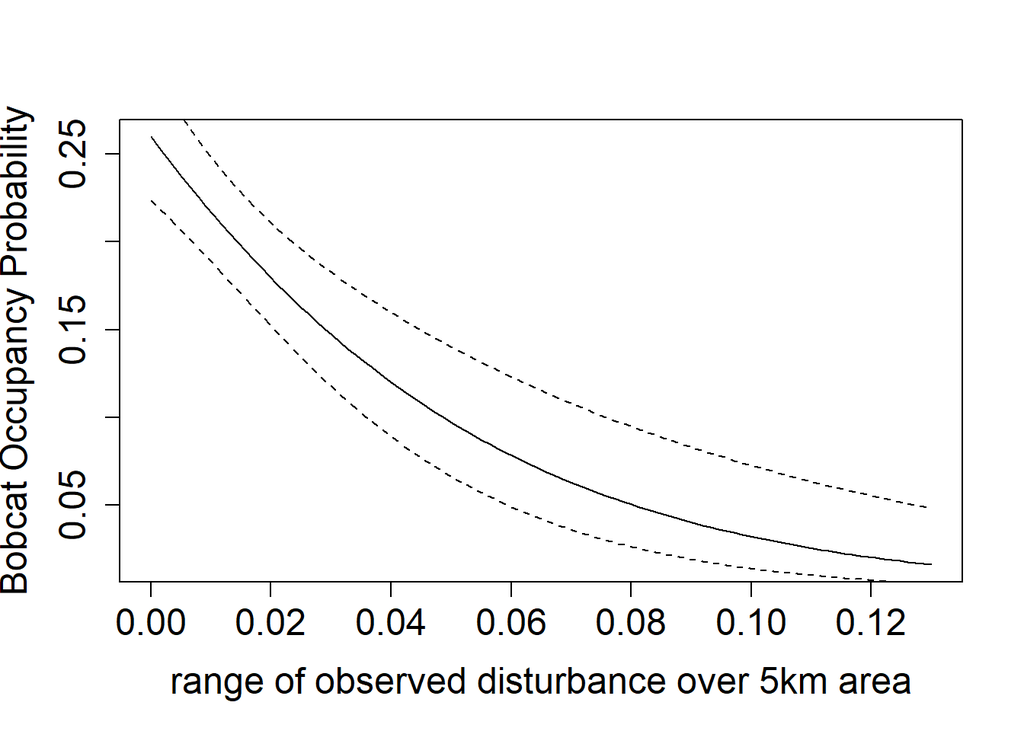

```r
#predictions of distance
dist_dat <- data.frame(Dist_5km = seq(from = min(site_covs$Dist_5km),
                                to = max(site_covs$Dist_5km),
                                length.out = 100)
)

dist_prd <- modavgPred(cand.set = cand.set,
                       newdata = dist_dat,
                       second.ord = F,
                       parm.type = 'psi')
plot(x = dist_dat$Dist_5km, y = dist_prd$mod.avg.pred,
     ylab = 'Bobcat Occupancy Probability',
     xlab = 'range of observed disturbance over 5km area',
     cex.axis = 1.5,
     cex.lab = 1.5,
     type = 'l');lines(y = dist_prd$lower.CL, x = dist_dat$Dist_5km, lty = 2); lines(y = dist_prd$upper.CL, x = dist_dat$Dist_5km, lty = 2)
```